# covid19_MI_prediction

### DATASET CREATION AND INTEGRATION

The datasets include

- *counties.csv*, which contains the list of counties in Michigan, along with locations of their nearby weather stations.
- *michigan.csv*, which contains the daily covid-19 cases reported for each county in Michigan, downloaded from https://www.michigan.gov/documents/coronavirus/Cases_and_Deaths_by_County_and_by_Date_of_Symptom_Onset_or_by_Date_of_Death2021-10-20_738873_7.xlsx
- *mobility.csv*, which contains Apple mobility trends report downloaded from https://covid19.apple.com/mobility.
- *weather.csv*. which contains daily weather data downloaded from https://www.ncdc.noaa.gov/cdo-web/search?datasetid=GHCND

```python
import pandas as pd
import numpy as np

class CountyData:
    def __init__(self, counties, stations):
        """
         A constructor function to initialize the state of the object. You will need to store the following
         variables: list of counties and their associated weather stations, number of daily cases per county,
         relative volume for each mobility pattern (driving, walking, and transit), and their daily weather
         information (precipitation, maximum and minimum temperature). You may use the following local variables
         to store the data. You only need to store the data from March 1, 2020 to October 17, 2021 for each
         variable.
        """

        self.counties = counties     # variable to store list of counties in Michigan
        self.stations = stations       # variable to store list of weather stations associated with the counties

    def loadCasesData(self, covidFile):
        """
         Function to load the number of confirmed daily Covid19 cases for the different counties from
         the given input filename. You should use the Case status column to distinguish the confirmed
         from the probable cases. You may use the pandas DataFrame object named self.cases to store the
         number of cases for each county. The rows of the data frame should correspond to the different
         days while the columns are the counties. You should store only the data from March 1, 2020
         to October 17, 2021.
        """
        covidData = pd.read_csv(covidFile)
        confirmed_covidData = covidData[covidData[covidData.columns[2]] == "Confirmed"]
        confirmed_covidData['Date'] = pd.to_datetime(confirmed_covidData['Date'], format='%m/%d/%Y')
        confirmed_covidData = confirmed_covidData[confirmed_covidData['COUNTY'].isin(self.counties)]
        confirmed_covidData = confirmed_covidData.loc[(confirmed_covidData['Date'] >= '3/1/2020') & (confirmed_covidData['Date'] <= '10/17/2021')]
        confirmed_covidData = confirmed_covidData.iloc[:, [0] + [1] + [3]]
        self.cases = confirmed_covidData.groupby(['Date','COUNTY'])['Cases'].aggregate('first').unstack()
        self.cases.index.name=''
        self.cases.columns.name=''
        #self.cases = self.cases[counties]

    def loadMobilityData(self, mobilityFile):
        """
         Function to load the mobility data for the different counties from an input file. Note that there are
         several types of mobility modes in the raw data, including driving, walking, and transit. You may store
         the data for each mobility mode separately as pandas DataFrame objects. The row in each dataframe object
         corresponds to a day and the columns are the different counties. You should only store the mobility
         data for the dates between March 1, 2020 to October 17, 2021 (columns 55 to 650). Note that the same
         county name may appear in more than 1 state (e.g., Wayne county). Therefore, make sure you select only
         the rows where the sub-region column value is Michigan. Furthermore, note that some counties may have
         only driving data, but not transit and walking.
        """
        def loadTypeWiseMobility(data):
            data = data.drop(columns='transportation_type').T
            data.columns = data.iloc[0]
            data = data[1:]
            data.columns.name = ''
            data.columns = [i[:-7] for i in data.columns]
            data.index = pd.to_datetime(data.index)
            return data

        mobilityData = pd.read_csv(mobilityFile)
        mobilityData = mobilityData[mobilityData[mobilityData.columns[4]] == 'Michigan']
        mobilityData = mobilityData[mobilityData[mobilityData.columns[0]] != 'city']
        list_of_columns = []
        list_of_columns.append(1)
        list_of_columns.append(2)
        for i in range(54,650):
            list_of_columns.append(i)
        mobilityData = mobilityData[mobilityData.columns[list_of_columns]]
        driving_mobilityData = mobilityData[mobilityData[mobilityData.columns[1]] == 'driving']
        self.driving = loadTypeWiseMobility(driving_mobilityData)
        walking_mobilityData = mobilityData[mobilityData[mobilityData.columns[1]] == 'walking']
        self.walking = loadTypeWiseMobility(walking_mobilityData)
        transit_mobilityData = mobilityData[mobilityData[mobilityData.columns[1]] == 'transit']
        self.transit = loadTypeWiseMobility(transit_mobilityData)

    def loadWeatherData(self, weatherFile):
        """
         Function to load the weather data for the various counties from an input file. You need the names of
         the weather station associated with each county (e.g., Lansing for Ingham County). You should store
         only the weather data for the dates between March 1, 2020 to October 17, 2021. Note that there are
         3 types of weather variables (precipitation, maximum daily temperature, and minimum daily
         temperature). You may store each weather variable separately as pandas dataframe objects. The row
         in each dataframe object corresponds to a day and the columns are the different counties.
        """
        def loadTypeWiseWeather(data):
            data = data.groupby([data.columns[1],data.columns[0]])[data.columns[2]].aggregate('first').unstack()
            data.index.name=''
            data.columns.name=''
            return data

        weatherData = pd.read_csv(weatherFile)
        weatherData['DATE'] = pd.to_datetime(weatherData['DATE'], format="%m/%d/%Y")
        weatherData = weatherData.loc[(weatherData['DATE'] >= '3/1/2020') & (weatherData['DATE'] <= '10/17/2021')]
        weatherData = pd.merge(locations,weatherData,left_on=['STATION'],right_on=['NAME']).drop(columns=['STATION_x','STATION_y','NAME'])
        prcp_weatherData = weatherData[weatherData.columns[[0,1,2]]]
        tmax_weatherData = weatherData[weatherData.columns[[0,1,3]]]
        tmin_weatherData = weatherData[weatherData.columns[[0,1,4]]]
        self.prec = loadTypeWiseWeather(prcp_weatherData)
        self.tmax = loadTypeWiseWeather(tmax_weatherData)
        self.tmin = loadTypeWiseWeather(tmin_weatherData)

    def getData(self, county):
        """
         Function to retrieve the data for a given county. The function will take a county name as input and will
         return a matrix of size N x 6, where  N = 596 corresponds to the different dates (from March 1, 2020 to
         Oct 17, 2021) and the 6 columns correspond to the time series values of (driving, walking, transit,
         precipitation, maximum temperature, and minimum temperature) for the given county. The matrix can be
         stored either as a pandas DataFrame or a 2-dimensional numpy array object. In addition, the function
         will also return a vector of size N = 596, corresponding to the number of covid-19 cases for the county.
         The vector can be stored as a pandas Series object or a 1-dimensional numpy array.
        """
        data = pd.DataFrame()
        if county in self.driving.columns:
            data['Driving'] = self.driving[county]
        if county in self.walking.columns:
            data['Walking'] = self.walking[county]
        if county in self.transit.columns:
            data['Transit'] = self.transit[county]
        if county in self.prec.columns:
            data['Precipitation'] = self.prec[county]
        if county in self.tmax.columns:
            data['Tmax'] = self.tmax[county]
        if county in self.tmin.columns:
            data['Tmin'] = self.tmin[county]
        cases_data = self.cases[county].to_numpy()
        return data,cases_data
```

```python
covidFile = 'data/michigan.csv'
mobilityFile = 'data/mobility.csv'
weatherFile = 'data/weather.csv'
locations = pd.read_csv('data/counties.csv')

counties = locations[locations.columns[0]]
stations = locations[locations.columns[1]]

# If your code is running too slowly, you may remove some counties without weather data.
# This reduces the number of counties to 10
#
#mask = pd.notna(stations)
#counties = counties[mask]
#stations = stations[mask]

rawdata = CountyData(counties, stations)
rawdata.loadCasesData(covidFile)
rawdata.loadMobilityData(mobilityFile)
rawdata.loadWeatherData(weatherFile)
```

```python
(ingham, y) = rawdata.getData('Ingham')
ingham['cases'] = y

print('Display the data for Ingham county')
ingham
```

```
Display the data for Ingham county
```

|  | Driving | Walking | Transit | Precipitation | Tmax | Tmin | cases |
| --- | --- | --- | --- | --- | --- | --- | --- |
| 2020-03-01 | 86.87 | 24.92 | 18.8 | 0.00 | 47.0 | 21.0 | 0 |
| 2020-03-02 | 81.86 | 27.23 | 24.62 | 0.00 | 50.0 | 36.0 | 1 |
| 2020-03-03 | 84.95 | 29.96 | 22.16 | 0.00 | 45.0 | 30.0 | 1 |
| 2020-03-04 | 89.89 | 32.81 | 25.57 | 0.00 | 45.0 | 26.0 | 1 |
| 2020-03-05 | 94.06 | 31.19 | 22.05 | 0.02 | 49.0 | 22.0 | 0 |
| ... | ... | ... | ... | ... | ... | ... | ... |
| 2021-10-13 | 157.89 | 160.36 | 128.21 | 0.00 | 73.0 | 57.0 | 46 |
| 2021-10-14 | 168.6 | 160.77 | 147.84 | 0.30 | 76.0 | 57.0 | 58 |
| 2021-10-15 | 204.75 | 167.17 | 128.63 | 0.28 | 63.0 | 54.0 | 48 |
| 2021-10-16 | 179.18 | 146.2 | 81.73 | 0.07 | 57.0 | 46.0 | 24 |
| 2021-10-17 | 142.0 | 93.78 | 64.11 | 0.00 | 64.0 | 45.0 | 30 |

596 rows × 7 columns

```python
rawdata.cases.to_csv('generated_data/cases.csv')
rawdata.driving.to_csv('generated_data/driving.csv')
rawdata.walking.to_csv('generated_data/walking.csv')
rawdata.transit.to_csv('generated_data/transit.csv')
rawdata.prec.to_csv('generated_data/prec.csv')
rawdata.tmax.to_csv('generated_data/tmax.csv')
rawdata.tmin.to_csv('generated_data/tmin.csv')
```

## DATA EXPLORATION

Data exploration on the Covid-19 cases and mobility data for one or more counties in Michigan. Data exploration includes visualizing the data to detect interesting patterns or computing summary statistics to obtain the overall properties of the variables.

**Analysis:** Goal of this analysis is to identify the top 10 counties contributing to covid cases and plotting the percentage of contribution among them.

[output not shown]

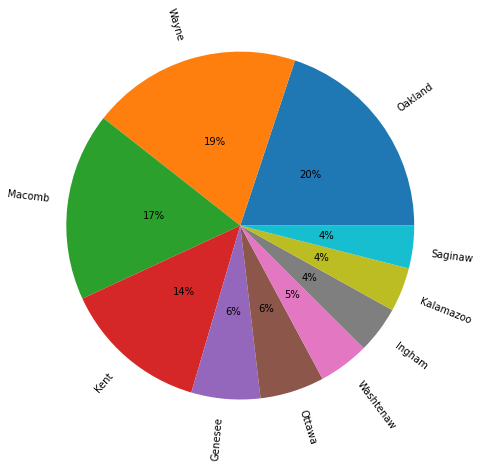

```python
import matplotlib.pyplot as plt
%matplotlib inline
cases = rawdata.cases
top_10_counties = cases.agg('sum').nlargest(n=10)
#top_10_counties_total = top_10_counties.agg('sum')
plt.figure(figsize=(12,8))
plt.pie(top_10_counties/top_10_counties.agg('sum'),labels=top_10_counties.index,autopct='%1.0f%%',pctdistance=0.5,labeldistance=1.1,rotatelabels=True)
```

**Findings from above analysis:**

The Top 10 counties contributed to cases are - Oakland, Wayne, Macomb, Kent, Genesee, Ottawa, Washtenaw,Ingham,Kalamazoo, and Saginaw.

Among these top 10, Oakland, Wayne, Macomb and Kent contributed around 70% of cases among themselves.

**Analysis:** Goal of this analysis is to identify the trends among the top 4 covid contributing counties

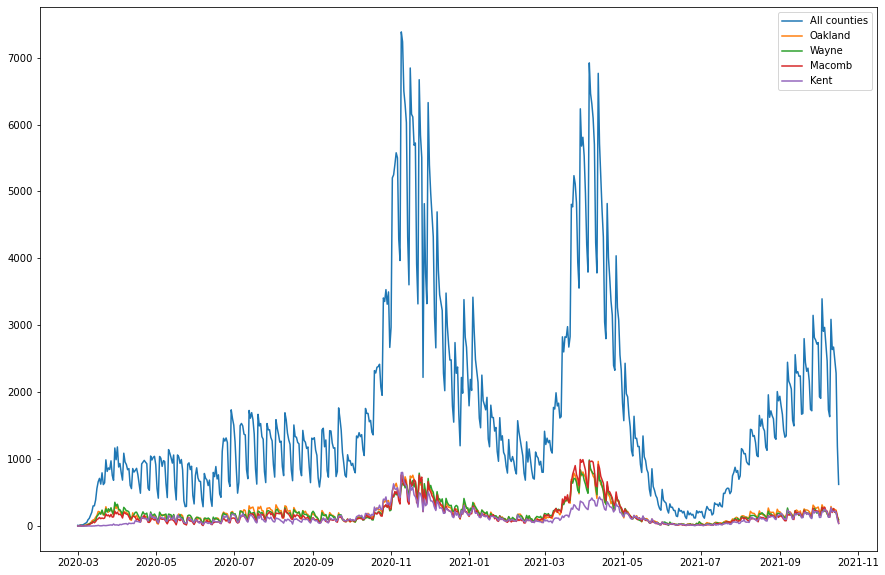

```python
total_cases = rawdata.cases.T.agg('sum')
#From analysis-1,Oakland, Wayne, Macomb and Kent are identified as top-4 contributers for covid cases
plt.figure(figsize=(15,10))
plt.plot(total_cases)
plt.plot(rawdata.cases['Oakland'])
plt.plot(rawdata.cases['Wayne'])
plt.plot(rawdata.cases['Macomb'])
plt.plot(rawdata.cases['Kent'])
plt.legend(["All counties","Oakland","Wayne","Macomb","Kent"])
```

**Findings from above analysis:** From the above time series, we can analyse that there was a steep raise in covid cases during the start of winter(November-January) and end of winter(April-June).

We if closely observe the blue line, there is regular peroidic dip(anamolies). This could be due to less number of covid testing and detection during the weekends.

**Analysis:** Goal of this analysis is to find the correlation among weather, mobility and cases data.(I've taken only 2 counties for this analysis - Wayne and Ingham)

```python
wayne,cases = rawdata.getData('Wayne')
wayne['cases'] = cases
ingham,cases = rawdata.getData('Ingham')
ingham['cases'] = cases
```

**Wayne County**

```
                Driving   Walking   Transit  Precipitation      Tmax  \
Driving        1.000000  0.944164  0.619892       0.051507  0.644141
Walking        0.944164  1.000000  0.536518      -0.003437  0.643105
Transit        0.619892  0.536518  1.000000      -0.010808  0.435909
Precipitation  0.051507 -0.003437 -0.010808       1.000000  0.079479
Tmax           0.644141  0.643105  0.435909       0.079479  1.000000
Tmin           0.637956  0.625207  0.439787       0.167078  0.934732
cases         -0.199891 -0.221190 -0.233617      -0.035193 -0.242891

                   Tmin     cases
Driving        0.637956 -0.199891
Walking        0.625207 -0.221190
Transit        0.439787 -0.233617
Precipitation  0.167078 -0.035193
Tmax           0.934732 -0.242891
Tmin           1.000000 -0.273529
cases         -0.273529  1.000000
```

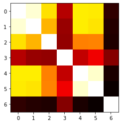

```python
wayne['Driving'] = np.float64(wayne['Driving'])
wayne['Walking'] = np.float64(wayne['Walking'])
wayne['Transit'] = np.float64(wayne['Transit'])
print(wayne.corr())
plt.imshow(wayne.corr(),cmap="hot",interpolation='nearest')
```

```
Driving         -0.199891
Walking         -0.221190
Transit         -0.233617
Precipitation   -0.035193
Tmax            -0.242891
Tmin            -0.273529
cases            1.000000
Name: cases, dtype: float64
```

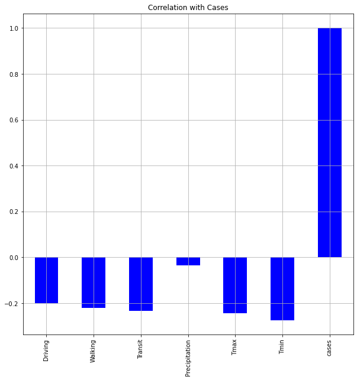

```python
print(wayne.corr()["cases"])
wayne.corrwith(wayne.cases).plot.bar(figsize = (10, 10), title = "Correlation with Cases", grid = True, color=['blue'])
```

**Findings from above analysis:** For Wayne county,we can infer from the above heatmap that the mobility and weather attributes are negatively related and relation is also weak.

**Ingham County**

```
                Driving   Walking   Transit  Precipitation      Tmax  \
Driving        1.000000  0.747572  0.641792       0.031625  0.525604
Walking        0.747572  1.000000  0.888213       0.000256  0.242489
Transit        0.641792  0.888213  1.000000       0.032220  0.196091
Precipitation  0.031625  0.000256  0.032220       1.000000  0.068188
Tmax           0.525604  0.242489  0.196091       0.068188  1.000000
Tmin           0.519567  0.250063  0.218479       0.169913  0.932138
cases          0.005432  0.023837  0.023270      -0.024798 -0.269008

                   Tmin     cases
Driving        0.519567  0.005432
Walking        0.250063  0.023837
Transit        0.218479  0.023270
Precipitation  0.169913 -0.024798
Tmax           0.932138 -0.269008
Tmin           1.000000 -0.246785
cases         -0.246785  1.000000
```

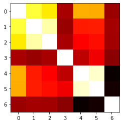

```python
ingham['Driving'] = np.float64(ingham['Driving'])
ingham['Walking'] = np.float64(ingham['Walking'])
ingham['Transit'] = np.float64(ingham['Transit'])
print(ingham.corr())
plt.imshow(ingham.corr(),cmap="hot",interpolation="nearest")
```

```
Driving          0.005432
Walking          0.023837
Transit          0.023270
Precipitation   -0.024798
Tmax            -0.269008
Tmin            -0.246785
cases            1.000000
Name: cases, dtype: float64
```

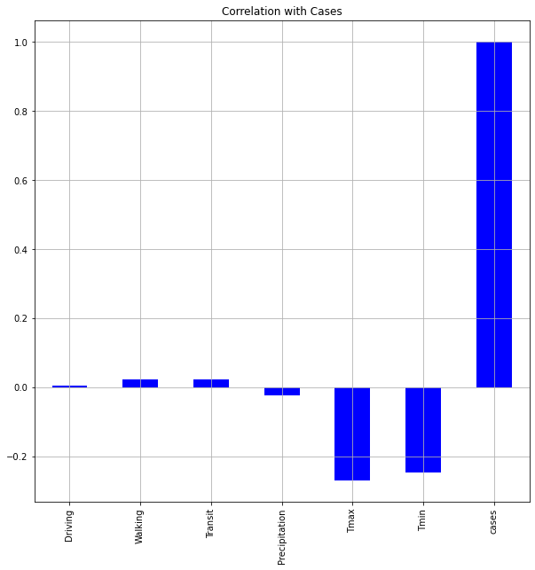

```python
print(ingham.corr()['cases'])
ingham.corrwith(ingham.cases).plot.bar(figsize = (10, 10), title = "Correlation with Cases", grid = True, color=['blue'])
```

**Findings from above analysis:** For Ingham county,we can infer from the above heatmap that the mobility attributes are positively related to cases and weather attributes are negatively related to cases and relationship is also weak.

**Analysis:** Goal of this analysis is to identify the how much weather columns are affecting cases column of Wayne county.

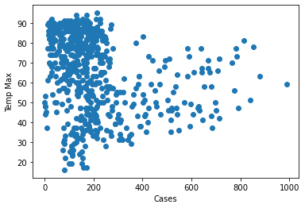

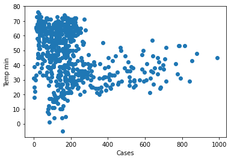

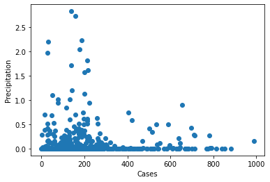

```python
wayne,cases = rawdata.getData('Wayne')
wayne['Cases'] = cases
plt.scatter(x=wayne.Cases,y=wayne.Tmax)
plt.xlabel("Cases")
plt.ylabel("Temp Max")
plt.show()
plt.scatter(x=wayne.Cases,y=wayne.Tmin)
plt.xlabel("Cases")
plt.ylabel("Temp min")
plt.show()
plt.scatter(x=wayne.Cases,y=wayne.Precipitation)
plt.xlabel("Cases")
plt.ylabel("Precipitation")
plt.show()
```

**Findings from above analysis:** From the above plots we can infer that the number of cases are less when the temperatures(both Tmax and Tmin) are higher. We cannot infer any relation between precipitation and cases.

**Analysis:** Goal of this analysis is to identify the outliers of a county attributes. (Performing only for Wayne county)

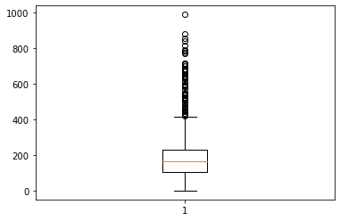

```python
wayne,cases = rawdata.getData('Wayne')
wayne['Cases'] = cases
plt.boxplot(wayne.Cases)
plt.show()
```

```python
q1 = np.quantile(wayne.Cases,0.25)
q3 = np.quantile(wayne.Cases,0.75)
med = np.median(wayne.Cases)
iqr = q3-q1
upper_bound = q3+(1.5*iqr)
lower_bound = q1-(1.5*iqr)
wayneCases1 = wayne.Cases[(wayne.Cases>=lower_bound) & (wayne.Cases<=upper_bound)]
print("Count-",len(wayne.Cases)-len(wayneCases1))
print("Percentage-",(len(wayne.Cases)-len(wayneCases1))/len(wayne.Cases)*100)
```

```
Count- 63
Percentage- 10.570469798657719
```

**Findings from above analysis:** The interquartile method found 63 outliers, which represents around 10.6% of the observations. Removing them would be a bad idea due to loss of a large amount of information.

**Major takeaways from the above exploratory analysis are -**

1) Out of 83 counties in Michigan, only few counties like Oakland, Wayne, Macomb, Kent are hotspot clusters for covid-19.

2) From the timeseries analysis and scatter plots, we can conculde that more cases have been reported during the winters( Less Tmin and Tmax).

3) Weather, mobility and cases of any county are weakly related.

4) Removal of outliers will result in loss of important information,thus affecting prediction models.

**Moving Average**

```python
import matplotlib.pyplot as plt
%matplotlib inline

def movingAverage(data, interval, agg='mean'):
    cols = data.columns
    df = pd.DataFrame(columns=cols,index=data.index)
    for i in cols:
        l = data[i]
        j = 0
        avg = []
        if agg == 'mean':
            while j < len(l) - interval + 1:
                current_window = l[j :j + interval ]
                mov_avg = sum(current_window)/interval
                avg.append(mov_avg)
                j+=1
        if agg == 'sum':
            while j < len(l) - interval + 1:
                current_window = l[j :j + interval ]
                mov_avg = sum(current_window)
                avg.append(mov_avg)
                j+=1
        if interval == 7:
            avg = [np.nan,np.nan,np.nan,np.nan,np.nan,np.nan]+avg
        if interval == 5:
            avg = [np.nan,np.nan,np.nan,np.nan]+avg
        if interval == 3:
            avg = [np.nan,np.nan]+avg
        df[i] = avg
    return df
```

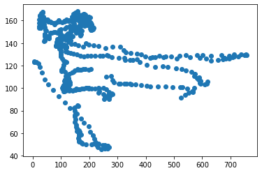

```python
interval_width = 7   # 7-day moving average

mv_cases = movingAverage(rawdata.cases, interval_width, 'mean')
mv_driving = movingAverage(rawdata.driving, interval_width, 'mean')
plt.scatter(mv_cases['Wayne'], mv_driving['Wayne'])
```

**Data Standardization**

```python
def standardize(data):
    return (data - data.mean())/data.std()
```

## Clustering

GMM Model to cluster Covid-19 Data

```python
from scipy.stats import multivariate_normal
from sklearn import cluster
import math

class GMM:
    def __init__(self, data):
        """
         A constructor function to initialize the state of the object. You will need to store the dataset to
         be clustered.
        """
        return



    def fit(self,data,numClusters=3, maxiter=50):
        """
         This function takes the number of clusters and maximum number of iterations to cluster the data.
         The function will initialize the values for the mean vector, covariance matrix, and
         membership value (pi) for each cluster before iteratively updating them using EM algorithm. You may
         apply methods such as k-means to cluster the data first and then use the cluster labels to compute
         the initial values for the mean vector, covariance matrix, and membership value (pi). The function
         should return a vector that contains the cluster membership of each data point.
        """
        def calculate_LL(data,Q,Pi,Mu,Sigma):
            N,K = Q.shape
            s = 0
            for n in range(N):
                for k in range(K):
                    s += Q[n,k]*math.log(Pi[k])
                    s += Q[n,k]*multivariate_normal.logpdf(data[n], mean=Mu[:,k],cov=Sigma[k], allow_singular=True)
            return s


        rows,cols = data.shape
        Z = cluster.KMeans(n_clusters=3, random_state=0).fit_predict(data)
        Q = np.zeros((rows, numClusters))
        Q[np.arange(rows),Z] = 1
        flag = False
        j = 0
        while j <= maxiter:
            sum_q = np.sum(Q, axis=0)
            Pi = sum_q/rows
            Mu = np.dot(data.T,Q)/sum_q
            Sigma = np.zeros((numClusters,cols,cols))
            for i in range(numClusters):
                for n in range(rows):
                    data_mu = np.reshape(data[n]-Mu[:,i],(cols,1))
                    Sigma[i] += Q[n,i]*np.dot(data_mu,data_mu.T)
                Sigma[i] /= sum_q[i]
            if not flag:
                Loglikelihood = calculate_LL(data,Q,Pi,Mu,Sigma)
                flag = True
            else:
                previousLL = Loglikelihood
                Loglikelihood = calculate_LL(data,Q,Pi,Mu,Sigma)
                if (math.fabs(Loglikelihood-previousLL) < 1e-1):
                    break
            for n in range(rows):
                for i in range(numClusters):
                    prob = multivariate_normal.pdf(data[n], mean=Mu[:,i], cov=Sigma[i],allow_singular=True)
                    Q[n,i] = Pi[i]*prob
                Q[n] /= np.sum(Q[n])
        return Q




    def display(self, clusters, county_names):
        """
         This function takes the clustering results and display the names of counties associated with each cluster.
        """
        cluster_1,cluster_2,cluster_3 = [],[],[]
        for i in range(len(clusters)):
            if clusters[i] == 0:
                cluster_1.append(county_names[i])
            elif clusters[i] == 1:
                cluster_2.append(county_names[i])
            else:
                cluster_3.append(county_names[i])
        print("Counties in cluster 1 - ", cluster_1)
        print("\nCounties in cluster 2 - ", cluster_2)
        print("\nCounties in cluster 3 - ", cluster_3)
```

```python
from sklearn.decomposition import PCA
numClusters = 3
pca = PCA(n_components=2)
rawdata.cases.dropna(inplace=True)
std_data = standardize(rawdata.cases)# standardize the time series data for each county
std_data = std_data.T
std_data = pca.fit_transform(std_data)
gmm = GMM(std_data)
clusters = gmm.fit(std_data, numClusters)
clusters1 = np.argmax(clusters,1)
gmm.display(clusters1, rawdata.counties)
```

[output not shown]

## Regression

```python
def QR_GS(A):
    Q = A.copy()
    R = np.zeros(A.shape)
    Q[:,0] = Q[:,0]/np.linalg.norm(Q[:,0])
    R[0,0] = np.dot(A[:,0].T,Q[:,0])
    for i in range(1,A.shape[1]):
        for j in range(i):
            R[j,i] = np.dot(A[:,i].T,Q[:,j])
            Q[:,i] = Q[:,i] - R[j,i]*Q[:,j]
        Q[:,i] = Q[:,i]/np.linalg.norm(Q[:,i])
        R[i,i] = np.dot(A[:,i].T,Q[:,i])
    return (Q, R)
```

```python
def QR_GR(A):
    Q = np.eye(A.shape[1])
    R = A.copy()
    for j in range(A.shape[1]-1):
        for i in range(A.shape[0]-1,j,-1):
            s = -R[i,j]/np.sqrt(R[i,j]**2+R[i-1,j]**2)
            c = R[i-1,j]/np.sqrt(R[i,j]**2+R[i-1,j]**2)
            G = np.eye(A.shape[1])
            G[i-1,i-1] = c
            G[i-1,i] = -s
            G[i,i-1] = s
            G[i,i] = c
            Q = np.matmul(Q,G.T)
            R = np.matmul(G,R)

    return (Q, R)
```

```python
def backsubstitution(U, b):
    m, n = U.shape

    for i in range(n-1,-1,-1):
        if U[i,i] == 0:
            b[i] = 0
        else:
            b[i] = b[i]/U[i,i]
            for j in range(i+1, n):
                b[i] -= U[i,j] * b[j] / U[i,i]
    return b
```

```python
def mlr_train(Xtrain, Ytrain,method="QR_GS"):

    A = np.dot(Xtrain.T, Xtrain)
    b = np.dot(Xtrain.T, Ytrain)
    if method=='QR_GS':
        print('QR using Gram-Schmidt orthogonalization')
        [Q,R] = QR_GS(A)
    else:
        print('QR using Givens rotation')
        [Q,R] = QR_GR(A)
    b = np.dot(Q.T, b)
    return backsubstitution(R,b)
```

```python
def mlr_predict(Xtest, w):
    return np.dot(Xtest, w)
```

```python
from sklearn.model_selection import train_test_split
import matplotlib.pyplot as plt
%matplotlib inline
```

```python
def getCountyData(county):
    df,y = rawdata.getData(county)
    df['Cases'] = y
    mvg_cases_7 = movingAverage(rawdata.cases,7,"mean")
    mvg_cases_7.fillna(0,inplace=True)
    mvg_cases_5 = movingAverage(rawdata.cases,5,"mean")
    mvg_cases_5.fillna(0,inplace=True)
    mvg_cases_3 = movingAverage(rawdata.cases,3,"mean")
    mvg_cases_3.fillna(0,inplace=True)
    df['Mvg_Cases_7'] = mvg_cases_7[county]
    df['Mvg_Cases_5'] = mvg_cases_5[county]
    df['Mvg_Cases_3'] = mvg_cases_3[county]
    day = []
    for i in range(len(df)):
        t = pd.Timestamp(df.index[i])
        day.append(t.day_of_week)
    df['Day'] = day
    df['Weekend'] = day
    df['Weekend'] = df['Weekend'].replace({1:0,2:0,3:0,4:0,5:1,6:1})
    df = standardize(df)
    df.dropna(inplace=True)
    return df
```

```python
def model_train(X_train,y_train):
    w = mlr_train(X_train,y_train,"QR_GR")
    print('Regression coefficients: ', w[:-1])
    print('Model Intercept: ', w[-1], '\n')
    return w
```

```python
def model_test(X_test,y_test,w):
    return mlr_predict(X_test, w)
```

```python
def model_predict(X_forecast,w,county):
    #return mlr_predict(X_forecast, w)
    pred = mlr_predict(X_forecast, w)
    pred = pred*rawdata.cases.std()[county]+rawdata.cases.mean()[county]
    return pred
```

```python
def model_plot(y_test,y_pred):
    plt.scatter(y_test,y_pred,color='black')
    plt.xlabel('Actual value')
    plt.ylabel('Predicted value')
    plt.show()
```

```
QR using Givens rotation
Regression coefficients:  [0.018752509870789486 0.014959753723884122 -0.0575471211411144
 0.048018090537228664 -0.04334341108089826 0.11487425960856368
 0.8817978993917136 -0.18734064314267043]
Model Intercept:  0.05303844959753523
```

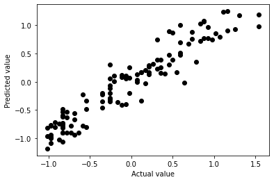

```
Root mean-square error on Standardized data of County: Allegan  is  0.21529931794139942
Model forecast for next  4  days is  [38 34 27 13]
Actual forecast for next  4  days is  [41, 30, 11, 6]
QR using Givens rotation
Regression coefficients:  [0.00666033160084994 -0.0009123371501382066 -0.016136514565346025
 0.03614649390269612 -0.03872322395368946 0.1396041729091989
 -0.04116773745478053 0.8453716210227215 -0.21153465636236884]
Model Intercept:  0.033060175195740185
```

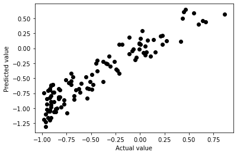

```
Root mean-square error on Standardized data of County: Genesee  is  0.1688914323460024
Model forecast for next  4  days is  [106 103 86 61]
Actual forecast for next  4  days is  [127, 93, 82, 35]
QR using Givens rotation
Regression coefficients:  [0.0013663798646195088 -0.021114697897824226 0.04110340550815341
 -0.03162239234267114 -0.013035039931034161 0.052491901961766674
 0.902480257050697 -0.16426126300495691]
Model Intercept:  0.04900753156391427
```

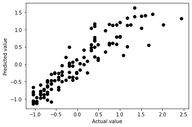

```
Root mean-square error on Standardized data of County: Grand Traverse  is  0.3170200188291415
Model forecast for next  4  days is  [22 24 21 13]
Actual forecast for next  4  days is  [27, 31, 6, 5]
QR using Givens rotation
Regression coefficients:  [-0.016374322474458088 0.03839982679702825 -0.031715968845763
 0.006611992390921064 -0.0021177638160792545 0.0098802482898033
 -0.05491708400341567 0.01275829334896783 0.9955423672407726
 -0.22620994470400085]
Model Intercept:  0.0808552926380898
```

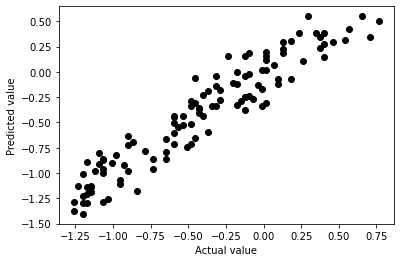

```
Root mean-square error on Standardized data of County: Ingham  is  0.16928360075641347
Model forecast for next  4  days is  [48 43 39 26]
Actual forecast for next  4  days is  [58, 48, 24, 30]
QR using Givens rotation
Regression coefficients:  [0.0023289458732941096 -0.0072886122112221785 0.0103126546922216
 -0.0008775467655784998 0.0355231814959259 -0.03156333348879299
 0.16297868458357587 -0.1636739276006293 0.9669975270049104
 -0.20613496728121217]
Model Intercept:  0.06464749077847913
```

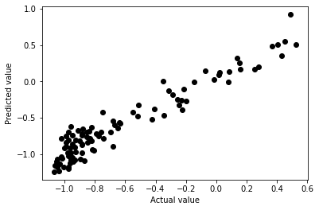

```
Root mean-square error on Standardized data of County: Kent  is  0.14279972463056234
Model forecast for next  4  days is  [196 204 209 133]
Actual forecast for next  4  days is  [239, 213, 207, 136]
QR using Givens rotation
Regression coefficients:  [0.028343750922053712 0.0199360699238911 0.0438502288517233
 -0.06440083841741853 -0.04292327779889313 0.1657149588809257
 0.8154769624398159 -0.1660732317850302]
Model Intercept:  0.04628646469077648
```

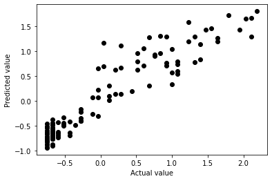

```
Root mean-square error on Standardized data of County: Marquette  is  0.29525489714083714
Model forecast for next  4  days is  [18 14 11 7]
Actual forecast for next  4  days is  [16, 11, 6, 8]
QR using Givens rotation
Regression coefficients:  [-0.0011060059728654177 -0.022043199542258342 -0.011786624618836181
 0.015224625855865079 0.036514336071734176 -0.20385639743010975
 1.1220394526684911 -0.10255630698731827]
Model Intercept:  0.058596427258609377
```

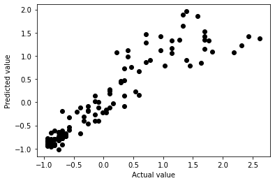

```
Root mean-square error on Standardized data of County: Midland  is  0.3519016482580105
Model forecast for next  4  days is  [38 31 27 18]
Actual forecast for next  4  days is  [36, 27, 19, 11]
QR using Givens rotation
Regression coefficients:  [-0.007542628343522145 -0.04086120930886728 -0.01221648481704614
 0.02508688037635782 0.18396304045380943 0.071474249553135
 0.6509303936210395 -0.2658206083433922]
Model Intercept:  0.012113469246261008
```

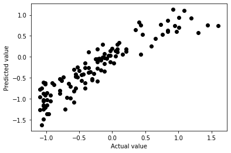

```
Root mean-square error on Standardized data of County: Saginaw  is  0.26269067628972415
Model forecast for next  4  days is  [76 56 38 18]
Actual forecast for next  4  days is  [70, 37, 24, 6]
QR using Givens rotation
Regression coefficients:  [0.013429096070105713 -0.007958171588997476 0.00575339673323727
 -0.008042469900325738 -0.028096407836007586 0.018871860872358856
 0.03795129382712412 -0.12878065551226592 1.0517254883573044
 -0.17699499157480975]
Model Intercept:  0.08786377659156695
```

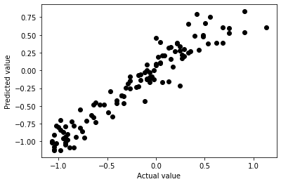

```
Root mean-square error on Standardized data of County: Washtenaw  is  0.16010950492538445
Model forecast for next  4  days is  [55 47 45 27]
Actual forecast for next  4  days is  [53, 47, 36, 11]
QR using Givens rotation
Regression coefficients:  [-0.021999283797991077 0.017802740734568334 0.024260047807151183
 0.0021332372354353566 0.03313319043834642 -0.04451341342025107
 -0.130622345077273 0.232482616464321 0.8582459169100234
 -0.24304468884426303]
Model Intercept:  0.06584177945518135
```

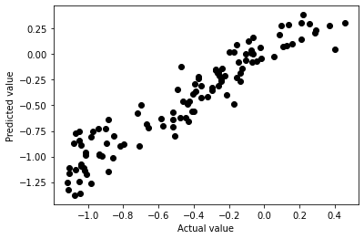

```
Root mean-square error on Standardized data of County: Wayne  is  0.1473859619608276
Model forecast for next  4  days is  [228 193 162 106]
Actual forecast for next  4  days is  [210, 199, 130, 95]
```

```python
for county in rawdata.tmax.columns:
    n = 4 # Number of prediction days
    df = getCountyData(county)
    train_size = int(0.8*len(df))
    train_set = df[:train_size]
    test_set = df[train_size:]
    y_train,y_test = train_set['Cases'],test_set['Cases']
    X_train,X_test = train_set.drop(columns='Cases',axis=1),test_set.drop(columns='Cases',axis=1)
    X_forecast = X_test[-n:]
    y_forecast_1 = y_test[-n:]
    X_test = X_test[:-n]
    y_test = y_test[:-n]
    w = model_train(X_train,y_train)
    y_pred = model_test(X_test,y_test,w)
    model_plot(y_test,y_pred)
    print('Root mean-square error on Standardized data of County:',county,' is ', np.sqrt(np.sum((y_test-y_pred)**2)/y_test.shape[0]))
    y_forecast = model_predict(X_forecast,w,county)
    actual_forecast = []
    for i in range(0,n):
        actual_forecast.append(y_forecast_1[i]*rawdata.cases.std()[county]+rawdata.cases.mean()[county])
    for i in range(n):
        y_forecast[i] = math.ceil(y_forecast[i])
        actual_forecast[i] = math.ceil(actual_forecast[i])
    print('Model forecast for next ',n,' days is ',y_forecast)
    print('Actual forecast for next ',n,' days is ',actual_forecast)
```

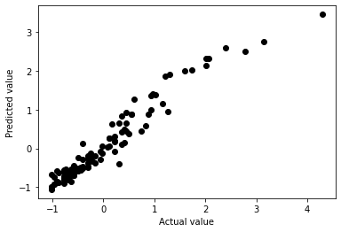

```
Root mean-square error on standardized data of County: Allegan  is  0.24124614539485137
Model forecast for next  4  days is  [5, 16, 29, 13]
Actual forecast for next  4  days is  [5, 14, 21, 11]
```

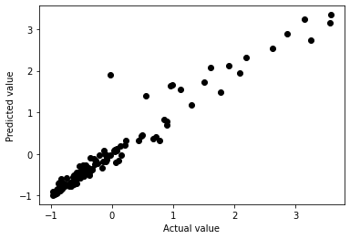

```
Root mean-square error on standardized data of County: Genesee  is  0.26785319308422234
Model forecast for next  4  days is  [12, 288, 38, 115]
Actual forecast for next  4  days is  [9, 323, 37, 127]
```

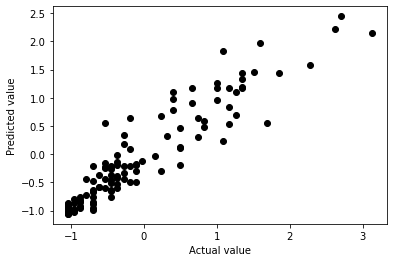

```
Root mean-square error on standardized data of County: Grand Traverse  is  0.3380512323253233
Model forecast for next  4  days is  [10, 8, 31, 9]
Actual forecast for next  4  days is  [8, 6, 29, 5]
```

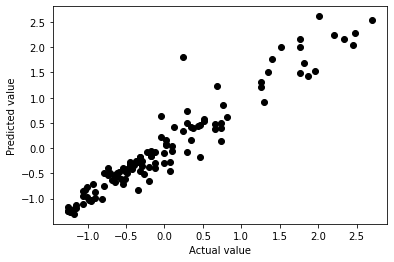

```
Root mean-square error on standardized data of County: Ingham  is  0.2777459210183509
Model forecast for next  4  days is  [46, 93, 31, 61]
Actual forecast for next  4  days is  [39, 101, 16, 59]
```

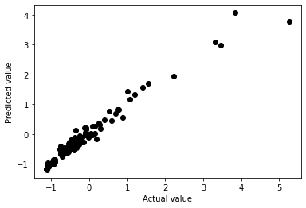

```
Root mean-square error on standardized data of County: Kent  is  0.2172536973552084
Model forecast for next  4  days is  [336, 187, 34, 126]
Actual forecast for next  4  days is  [290, 170, 31, 120]
```

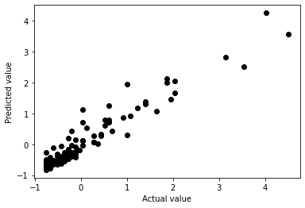

```
Root mean-square error on standardized data of County: Marquette  is  0.2850090673367757
Model forecast for next  4  days is  [10, 0, 13, 5]
Actual forecast for next  4  days is  [13, 1, 15, 6]
```

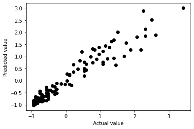

```
Root mean-square error on standardized data of County: Midland  is  0.27240456455056195
Model forecast for next  4  days is  [55, 3, 38, 53]
Actual forecast for next  4  days is  [68, 2, 36, 61]
```

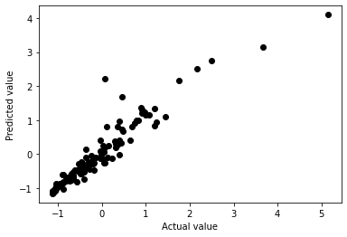

```
Root mean-square error on standardized data of County: Saginaw  is  0.32913836607121677
Model forecast for next  4  days is  [91, 52, 144, 25]
Actual forecast for next  4  days is  [101, 44, 151, 27]
```

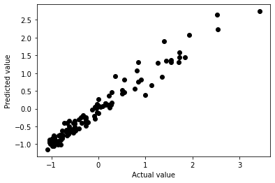

```
Root mean-square error on standardized data of County: Washtenaw  is  0.19035551175682625
Model forecast for next  4  days is  [24, 29, 132, 24]
Actual forecast for next  4  days is  [29, 34, 144, 29]
```

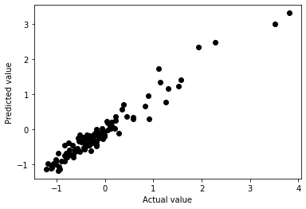

```
Root mean-square error on standardized data of County: Wayne  is  0.19405833471016426
Model forecast for next  4  days is  [245, 73, 566, 204]
Actual forecast for next  4  days is  [237, 119, 543, 214]
```

```python
from sklearn.model_selection import train_test_split
from sklearn.neural_network import MLPRegressor
for county in rawdata.tmax.columns:
    n = 4 # Number of prediction days
    clf = MLPRegressor(random_state=1,max_iter=100)
    df = getCountyData(county)
    y = df['Cases']
    X = df.drop(columns="Cases",axis=1)
    X_train,X_test,y_train,y_test = train_test_split(X,y,test_size=0.2,random_state=42)
    X_forecast = X_test[-n:]
    y_forecast_1 = y_test[-n:]
    X_test = X_test[:-n]
    y_test = y_test[:-n]
    clf.fit(X_train,y_train)
    y_pred = clf.predict(X_test)
    model_plot(y_test,y_pred)
    print('Root mean-square error on standardized data of County:',county,' is ', np.sqrt(np.sum((y_test-y_pred)**2)/y_test.shape[0]))
    y_forecast = clf.predict(X_forecast)
    actual_forecast = []
    y_forecast1 =[]
    for i in range(0,n):
        actual_forecast.append(y_forecast_1[i]*rawdata.cases[county].std()+rawdata.cases[county].mean())
        y_forecast1.append(y_forecast[i]*rawdata.cases[county].std()+rawdata.cases[county].mean())
    for i in range(0,n):
        actual_forecast[i] = math.ceil(actual_forecast[i])
        y_forecast1[i] = math.ceil(y_forecast1[i])
    print('Model forecast for next ',n,' days is ',y_forecast1)
    print('Actual forecast for next ',n,' days is ',actual_forecast)
```

**Performance Comparison** -From the above two models, we can infer that Model-1(Multiple Linear Regression) gives better results with less RMSE values than Model-2(MLP Regressor).